# Python bridge 3

[*John Pinney*](https://github.com/johnpinney)

*Part of this notebook is adapted from the Graduate School's 'Data Processing with Python Pandas' course.*

## Introduction

This session introduces the [pandas](https://pandas.pydata.org) package, which supports data processing in python.

Pandas makes it easier to build workflows that move between different kinds of task:

- Reading tabular data
- Tidying data
- Transforming data
- Data visualisation
- Applying statistical tests

If pandas is installed in your python environment, it's easy to import:

```python
import pandas as pd
```

## DataFrames

Pandas is built around a fundamental data object called a [DataFrame](https://pandas.pydata.org/pandas-docs/stable/reference/frame.html).

Here's how you can create one from a python [dict](https://docs.python.org/3/tutorial/datastructures.html#dictionaries):

```python
planets = pd.DataFrame({
    'name' : ["Mercury", "Venus", "Earth", "Mars", "Jupiter", "Saturn", "Uranus", "Neptune"],
    'type' : ["Terrestrial", "Terrestrial", "Terrestrial", "Terrestrial", "Gas giant", "Gas giant", "Ice giant", "Ice giant"],
    'mass' : [0.0553, 0.815, 1, 0.107, 317.8, 95.2, 14.5, 17.1],
    'diameter' : [0.383, 0.949, 1, 0.532, 11.21, 9.45, 4.01, 3.88],
    'distance_from_sun' : [0.387, 0.723, 1, 1.52, 5.20, 9.58, 19.2, 30.05],
    'orbital_period' : [0.241, 0.615, 1, 1.88, 11.9, 29.4, 83.7, 163.7],
    'rings' : [False, False, False, False, True, True, True, True]
})

planets
```

|  | name | type | mass | diameter | distance_from_sun | orbital_period | rings |
| --- | --- | --- | --- | --- | --- | --- | --- |
| 0 | Mercury | Terrestrial | 0.0553 | 0.383 | 0.387 | 0.241 | False |
| 1 | Venus | Terrestrial | 0.8150 | 0.949 | 0.723 | 0.615 | False |
| 2 | Earth | Terrestrial | 1.0000 | 1.000 | 1.000 | 1.000 | False |
| 3 | Mars | Terrestrial | 0.1070 | 0.532 | 1.520 | 1.880 | False |
| 4 | Jupiter | Gas giant | 317.8000 | 11.210 | 5.200 | 11.900 | True |
| 5 | Saturn | Gas giant | 95.2000 | 9.450 | 9.580 | 29.400 | True |
| 6 | Uranus | Ice giant | 14.5000 | 4.010 | 19.200 | 83.700 | True |
| 7 | Neptune | Ice giant | 17.1000 | 3.880 | 30.050 | 163.700 | True |

The variable `planets` now points to a DataFrame object containing our data.

Notice how our DataFrame contains data of different types. This is something that wouldn't be possible using a numpy `ndarray` (where every piece of data would have to be of the same type).

```python
planets.head(3)
```

|  | name | type | mass | diameter | distance_from_sun | orbital_period | rings |
| --- | --- | --- | --- | --- | --- | --- | --- |
| 0 | Mercury | Terrestrial | 0.0553 | 0.383 | 0.387 | 0.241 | False |
| 1 | Venus | Terrestrial | 0.8150 | 0.949 | 0.723 | 0.615 | False |
| 2 | Earth | Terrestrial | 1.0000 | 1.000 | 1.000 | 1.000 | False |

The attribute [`shape`](https://pandas.pydata.org/pandas-docs/stable/reference/api/pandas.DataFrame.shape.html) holds the dimensions of the DataFrame as (#rows, #columns) :

```python
planets.shape
```

```
(8, 7)
```

A pandas DataFrame has many other useful [methods](https://pandas.pydata.org/pandas-docs/stable/reference/frame.html#computations-descriptive-stats) and [attributes](https://pandas.pydata.org/pandas-docs/stable/reference/frame.html#attributes-and-underlying-data).

##### *Exercise 1a*

1. What do the following methods do?

[`tail`](https://pandas.pydata.org/pandas-docs/stable/reference/api/pandas.DataFrame.tail.html), [`sample`](https://pandas.pydata.org/pandas-docs/stable/reference/api/pandas.DataFrame.sample.html), [`describe`](https://pandas.pydata.org/pandas-docs/stable/reference/api/pandas.DataFrame.describe.html), [`copy`](https://pandas.pydata.org/pandas-docs/stable/reference/api/pandas.DataFrame.copy.html)

```python
planets.tail() # selects the last 5 rows
```

|  | name | type | mass | diameter | distance_from_sun | orbital_period | rings |
| --- | --- | --- | --- | --- | --- | --- | --- |
| 3 | Mars | Terrestrial | 0.107 | 0.532 | 1.52 | 1.88 | False |
| 4 | Jupiter | Gas giant | 317.800 | 11.210 | 5.20 | 11.90 | True |
| 5 | Saturn | Gas giant | 95.200 | 9.450 | 9.58 | 29.40 | True |
| 6 | Uranus | Ice giant | 14.500 | 4.010 | 19.20 | 83.70 | True |
| 7 | Neptune | Ice giant | 17.100 | 3.880 | 30.05 | 163.70 | True |

```python
planets.sample() # selects one row at random
```

|  | name | type | mass | diameter | distance_from_sun | orbital_period | rings |
| --- | --- | --- | --- | --- | --- | --- | --- |
| 2 | Earth | Terrestrial | 1.0 | 1.0 | 1.0 | 1.0 | False |

```python
planets.describe() # calculates summary statistics
```

|  | mass | diameter | distance_from_sun | orbital_period |
| --- | --- | --- | --- | --- |
| count | 8.000000 | 8.000000 | 8.000000 | 8.000000 |
| mean | 55.822163 | 3.926750 | 8.457500 | 36.554500 |
| std | 110.605675 | 4.227064 | 10.837813 | 58.705645 |
| min | 0.055300 | 0.383000 | 0.387000 | 0.241000 |
| 25% | 0.638000 | 0.844750 | 0.930750 | 0.903750 |
| 50% | 7.750000 | 2.440000 | 3.360000 | 6.890000 |
| 75% | 36.625000 | 5.370000 | 11.985000 | 42.975000 |
| max | 317.800000 | 11.210000 | 30.050000 | 163.700000 |

```python
planets.copy() # returns a copy of the DataFrame
```

|  | name | type | mass | diameter | distance_from_sun | orbital_period | rings |
| --- | --- | --- | --- | --- | --- | --- | --- |
| 0 | Mercury | Terrestrial | 0.0553 | 0.383 | 0.387 | 0.241 | False |
| 1 | Venus | Terrestrial | 0.8150 | 0.949 | 0.723 | 0.615 | False |
| 2 | Earth | Terrestrial | 1.0000 | 1.000 | 1.000 | 1.000 | False |
| 3 | Mars | Terrestrial | 0.1070 | 0.532 | 1.520 | 1.880 | False |
| 4 | Jupiter | Gas giant | 317.8000 | 11.210 | 5.200 | 11.900 | True |
| 5 | Saturn | Gas giant | 95.2000 | 9.450 | 9.580 | 29.400 | True |
| 6 | Uranus | Ice giant | 14.5000 | 4.010 | 19.200 | 83.700 | True |
| 7 | Neptune | Ice giant | 17.1000 | 3.880 | 30.050 | 163.700 | True |

1. To what do the following attributes refer?

[`size`](https://pandas.pydata.org/pandas-docs/stable/reference/api/pandas.DataFrame.size.html), [`dtypes`](https://pandas.pydata.org/pandas-docs/stable/reference/api/pandas.DataFrame.dtypes.html), [`columns`](https://pandas.pydata.org/pandas-docs/stable/reference/api/pandas.DataFrame.columns.html), [`values`](https://pandas.pydata.org/pandas-docs/stable/reference/api/pandas.DataFrame.values.html)

```python
planets.size # the total number of data values (cells)
```

```
56
```

```python
planets.dtypes # the data type for each column
```

```
name                  object
type                  object
mass                 float64
diameter             float64
distance_from_sun    float64
orbital_period       float64
rings                   bool
dtype: object
```

```python
planets.columns # the column labels
```

```
Index(['name', 'type', 'mass', 'diameter', 'distance_from_sun',
       'orbital_period', 'rings'],
      dtype='object')
```

```python
planets.values # the data values as an array
```

```
array([['Mercury', 'Terrestrial', 0.0553, 0.383, 0.387, 0.241, False],
       ['Venus', 'Terrestrial', 0.815, 0.949, 0.723, 0.615, False],
       ['Earth', 'Terrestrial', 1.0, 1.0, 1.0, 1.0, False],
       ['Mars', 'Terrestrial', 0.107, 0.532, 1.52, 1.88, False],
       ['Jupiter', 'Gas giant', 317.8, 11.21, 5.2, 11.9, True],
       ['Saturn', 'Gas giant', 95.2, 9.45, 9.58, 29.4, True],
       ['Uranus', 'Ice giant', 14.5, 4.01, 19.2, 83.7, True],
       ['Neptune', 'Ice giant', 17.1, 3.88, 30.05, 163.7, True]],
      dtype=object)
```

## Accessing Data

Pandas provides several different ways to get data out of the DataFrame.

### Accessing single values

A single value can be accessed using [`iat[]`](https://pandas.pydata.org/pandas-docs/stable/reference/api/pandas.DataFrame.iat.html).

We can think of it as meaning "the value **at** an **i**nteger position".

It treats the DataFrame like an array with two *axes*.

The row coordinate is the first axis; the column coordinate is second.

```python
planets.iat[1,2]
```

```
0.815
```

### Accessing rows and columns

[`iloc[]`](https://pandas.pydata.org/pandas-docs/stable/reference/api/pandas.DataFrame.iloc.html) means "**loc**ate data by **i**nteger position".

It is used to access subsets of rows and columns, using the same coordinate system as `iat[]`.

#### Selecting rows

We can use `iloc[]` with a slice to get a subset of rows:

```python
planets.iloc[2:4]
```

|  | name | type | mass | diameter | distance_from_sun | orbital_period | rings |
| --- | --- | --- | --- | --- | --- | --- | --- |
| 2 | Earth | Terrestrial | 1.000 | 1.000 | 1.00 | 1.00 | False |
| 3 | Mars | Terrestrial | 0.107 | 0.532 | 1.52 | 1.88 | False |

Because *slicing rows* is such a common operation, pandas also provides a shortcut:

```python
planets[2:4]
```

|  | name | type | mass | diameter | distance_from_sun | orbital_period | rings |
| --- | --- | --- | --- | --- | --- | --- | --- |
| 2 | Earth | Terrestrial | 1.000 | 1.000 | 1.00 | 1.00 | False |
| 3 | Mars | Terrestrial | 0.107 | 0.532 | 1.52 | 1.88 | False |

Alternatively, we can provide `iloc[]` with a list of the indices to select:

```python
planets.iloc[[1,3,5]]
```

|  | name | type | mass | diameter | distance_from_sun | orbital_period | rings |
| --- | --- | --- | --- | --- | --- | --- | --- |
| 1 | Venus | Terrestrial | 0.815 | 0.949 | 0.723 | 0.615 | False |
| 3 | Mars | Terrestrial | 0.107 | 0.532 | 1.520 | 1.880 | False |
| 5 | Saturn | Gas giant | 95.200 | 9.450 | 9.580 | 29.400 | True |

##### *Exercise 1b*

1. Select the last three rows.

```python
planets[-3:]
```

|  | name | type | mass | diameter | distance_from_sun | orbital_period | rings |
| --- | --- | --- | --- | --- | --- | --- | --- |
| 5 | Saturn | Gas giant | 95.2 | 9.45 | 9.58 | 29.4 | True |
| 6 | Uranus | Ice giant | 14.5 | 4.01 | 19.20 | 83.7 | True |
| 7 | Neptune | Ice giant | 17.1 | 3.88 | 30.05 | 163.7 | True |

1. Select three rows at random.

```python
planets.sample(3)
```

|  | name | type | mass | diameter | distance_from_sun | orbital_period | rings |
| --- | --- | --- | --- | --- | --- | --- | --- |
| 3 | Mars | Terrestrial | 0.1070 | 0.532 | 1.520 | 1.880 | False |
| 1 | Venus | Terrestrial | 0.8150 | 0.949 | 0.723 | 0.615 | False |
| 0 | Mercury | Terrestrial | 0.0553 | 0.383 | 0.387 | 0.241 | False |

1. Make a DataFrame containing only the first row.

```python
planets.iloc[[0]]
```

|  | name | type | mass | diameter | distance_from_sun | orbital_period | rings |
| --- | --- | --- | --- | --- | --- | --- | --- |
| 0 | Mercury | Terrestrial | 0.0553 | 0.383 | 0.387 | 0.241 | False |

1. Make a DataFrame containing the first, second and last rows.

```python
planets.iloc[[0,1,-1]]
```

|  | name | type | mass | diameter | distance_from_sun | orbital_period | rings |
| --- | --- | --- | --- | --- | --- | --- | --- |
| 0 | Mercury | Terrestrial | 0.0553 | 0.383 | 0.387 | 0.241 | False |
| 1 | Venus | Terrestrial | 0.8150 | 0.949 | 0.723 | 0.615 | False |
| 7 | Neptune | Ice giant | 17.1000 | 3.880 | 30.050 | 163.700 | True |

#### Selecting columns

We can access columns by integer using the second axis of `iloc[]`:

```python
planets.iloc[:,2]
```

```
0      0.0553
1      0.8150
2      1.0000
3      0.1070
4    317.8000
5     95.2000
6     14.5000
7     17.1000
Name: mass, dtype: float64
```

Using an integer index (e.g. `2` above), this returns the column values in the form of a pandas [Series](https://pandas.pydata.org/pandas-docs/stable/reference/series.html) object.

```python
planets.iloc[:,[2,3]]
```

|  | mass | diameter |
| --- | --- | --- |
| 0 | 0.0553 | 0.383 |
| 1 | 0.8150 | 0.949 |
| 2 | 1.0000 | 1.000 |
| 3 | 0.1070 | 0.532 |
| 4 | 317.8000 | 11.210 |
| 5 | 95.2000 | 9.450 |
| 6 | 14.5000 | 4.010 |
| 7 | 17.1000 | 3.880 |

Notice that we still need to provide a placeholder `:` before the comma, to indicate "all of the rows".

Using a slice or list after the comma returns a subset of columns:

```python
planets.iloc[:,2:4]
```

|  | mass | diameter |
| --- | --- | --- |
| 0 | 0.0553 | 0.383 |
| 1 | 0.8150 | 0.949 |
| 2 | 1.0000 | 1.000 |
| 3 | 0.1070 | 0.532 |
| 4 | 317.8000 | 11.210 |
| 5 | 95.2000 | 9.450 |
| 6 | 14.5000 | 4.010 |
| 7 | 17.1000 | 3.880 |

However, accessing columns by position is not usually very convenient. We need to be able to refer to the columns by their *labels*.

### Accessing by label

[`loc[]`](https://pandas.pydata.org/pandas-docs/stable/reference/api/pandas.DataFrame.loc.html) means "locate by label". Our columns are labelled with strings.

```python
planets.loc[:,'name']
```

```
0    Mercury
1      Venus
2      Earth
3       Mars
4    Jupiter
5     Saturn
6     Uranus
7    Neptune
Name: name, dtype: object
```

This returns a Series object, which represents the data from a single column. The numbers shown next to the values are the *row labels*.

As a shortcut, we can also use `[]` with the *column labels* to select specified columns:

```python
planets['name']
```

```
0    Mercury
1      Venus
2      Earth
3       Mars
4    Jupiter
5     Saturn
6     Uranus
7    Neptune
Name: name, dtype: object
```

As an even shorter shortcut, column names are actually attributes:

```python
planets.name
```

```
0    Mercury
1      Venus
2      Earth
3       Mars
4    Jupiter
5     Saturn
6     Uranus
7    Neptune
Name: name, dtype: object
```

A list can be used to select multiple columns.

```python
planets[['name','mass']]
```

|  | name | mass |
| --- | --- | --- |
| 0 | Mercury | 0.0553 |
| 1 | Venus | 0.8150 |
| 2 | Earth | 1.0000 |
| 3 | Mars | 0.1070 |
| 4 | Jupiter | 317.8000 |
| 5 | Saturn | 95.2000 |
| 6 | Uranus | 14.5000 |
| 7 | Neptune | 17.1000 |

##### *Exercise 1c*

1. Select the first three rows, but only the **name** and **diameter** columns.

```python
planets[:3][['name','diameter']]
```

|  | name | diameter |
| --- | --- | --- |
| 0 | Mercury | 0.383 |
| 1 | Venus | 0.949 |
| 2 | Earth | 1.000 |

1. Select the first two columns for rows 4 and 6.

```python
planets.iloc[[4,6],:2]
```

|  | name | type |
| --- | --- | --- |
| 4 | Jupiter | Gas giant |
| 6 | Uranus | Ice giant |

1. Make a plot of `distance from sun` vs `orbital period`.

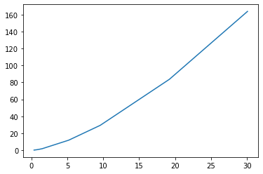

```python
import matplotlib.pyplot as plt
plt.plot(planets.distance_from_sun, planets.orbital_period)
```

## Querying, filtering and sorting data

Of course, we are not just limited to accessing data by position and label.

Here are some useful DataFrame methods for basic data manipulation:

### [`query`](https://pandas.pydata.org/pandas-docs/stable/reference/api/pandas.DataFrame.query.html)

selects rows according to whatever conditions we specify, e.g.:

```python
planets.query('name == "Earth"')
```

|  | name | type | mass | diameter | distance_from_sun | orbital_period | rings |
| --- | --- | --- | --- | --- | --- | --- | --- |
| 2 | Earth | Terrestrial | 1.0 | 1.0 | 1.0 | 1.0 | False |

```python
planets.query('diameter > 2')
```

|  | name | type | mass | diameter | distance_from_sun | orbital_period | rings |
| --- | --- | --- | --- | --- | --- | --- | --- |
| 4 | Jupiter | Gas giant | 317.8 | 11.21 | 5.20 | 11.9 | True |
| 5 | Saturn | Gas giant | 95.2 | 9.45 | 9.58 | 29.4 | True |
| 6 | Uranus | Ice giant | 14.5 | 4.01 | 19.20 | 83.7 | True |
| 7 | Neptune | Ice giant | 17.1 | 3.88 | 30.05 | 163.7 | True |

Note that the query is a Boolean expression, provided as a string `''`.

Inside the query, column names are unquoted and string values are quoted using `""`.

We can refer to columns containing spaces by enclosing them in backticks `` `` ``.

We can also refer to variables in the environment using the `@` prefix.

```python
max_period = 30
planets.query('rings and orbital_period < @max_period')
```

|  | name | type | mass | diameter | distance_from_sun | orbital_period | rings | density |
| --- | --- | --- | --- | --- | --- | --- | --- | --- |
| 4 | Jupiter | Gas giant | 317.8 | 11.21 | 5.20 | 11.9 | True | 0.225599 |
| 5 | Saturn | Gas giant | 95.2 | 9.45 | 9.58 | 29.4 | True | 0.112808 |

### [`filter`](https://pandas.pydata.org/pandas-docs/stable/reference/api/pandas.DataFrame.filter.html)

extracts a subset of columns by examining their **labels**, e.g.:

```python
planets.filter(['name','mass'])
```

[output not shown]

This is similar to `loc[]` but has some extra pattern-matching powers:

```python
planets.filter(like='am')
```

|  | name | diameter |
| --- | --- | --- |
| 0 | Mercury | 0.383 |
| 1 | Venus | 0.949 |
| 2 | Earth | 1.000 |
| 3 | Mars | 0.532 |
| 4 | Jupiter | 11.210 |
| 5 | Saturn | 9.450 |
| 6 | Uranus | 4.010 |
| 7 | Neptune | 3.880 |

```python
planets.filter(regex='^t')
```

|  | type |
| --- | --- |
| 0 | Terrestrial |
| 1 | Terrestrial |
| 2 | Terrestrial |
| 3 | Terrestrial |
| 4 | Gas giant |
| 5 | Gas giant |
| 6 | Ice giant |
| 7 | Ice giant |

### [`sort_values`](https://pandas.pydata.org/pandas-docs/stable/reference/api/pandas.DataFrame.sort_values.html)

returns a copy of the DataFrame, sorted by ascending column value:

```python
planets.sort_values('diameter')
```

|  | name | type | mass | diameter | distance_from_sun | orbital_period | rings |
| --- | --- | --- | --- | --- | --- | --- | --- |
| 0 | Mercury | Terrestrial | 0.0553 | 0.383 | 0.387 | 0.241 | False |
| 3 | Mars | Terrestrial | 0.1070 | 0.532 | 1.520 | 1.880 | False |
| 1 | Venus | Terrestrial | 0.8150 | 0.949 | 0.723 | 0.615 | False |
| 2 | Earth | Terrestrial | 1.0000 | 1.000 | 1.000 | 1.000 | False |
| 7 | Neptune | Ice giant | 17.1000 | 3.880 | 30.050 | 163.700 | True |
| 6 | Uranus | Ice giant | 14.5000 | 4.010 | 19.200 | 83.700 | True |
| 5 | Saturn | Gas giant | 95.2000 | 9.450 | 9.580 | 29.400 | True |
| 4 | Jupiter | Gas giant | 317.8000 | 11.210 | 5.200 | 11.900 | True |

...or by descending value using `ascending=False`:

```python
planets.sort_values('diameter', ascending=False)
```

|  | name | type | mass | diameter | distance_from_sun | orbital_period | rings |
| --- | --- | --- | --- | --- | --- | --- | --- |
| 4 | Jupiter | Gas giant | 317.8000 | 11.210 | 5.200 | 11.900 | True |
| 5 | Saturn | Gas giant | 95.2000 | 9.450 | 9.580 | 29.400 | True |
| 6 | Uranus | Ice giant | 14.5000 | 4.010 | 19.200 | 83.700 | True |
| 7 | Neptune | Ice giant | 17.1000 | 3.880 | 30.050 | 163.700 | True |
| 2 | Earth | Terrestrial | 1.0000 | 1.000 | 1.000 | 1.000 | False |
| 1 | Venus | Terrestrial | 0.8150 | 0.949 | 0.723 | 0.615 | False |
| 3 | Mars | Terrestrial | 0.1070 | 0.532 | 1.520 | 1.880 | False |
| 0 | Mercury | Terrestrial | 0.0553 | 0.383 | 0.387 | 0.241 | False |

The original DataFrame is unchanged:

```python
planets
```

|  | name | type | mass | diameter | distance_from_sun | orbital_period | rings |
| --- | --- | --- | --- | --- | --- | --- | --- |
| 0 | Mercury | Terrestrial | 0.0553 | 0.383 | 0.387 | 0.241 | False |
| 1 | Venus | Terrestrial | 0.8150 | 0.949 | 0.723 | 0.615 | False |
| 2 | Earth | Terrestrial | 1.0000 | 1.000 | 1.000 | 1.000 | False |
| 3 | Mars | Terrestrial | 0.1070 | 0.532 | 1.520 | 1.880 | False |
| 4 | Jupiter | Gas giant | 317.8000 | 11.210 | 5.200 | 11.900 | True |
| 5 | Saturn | Gas giant | 95.2000 | 9.450 | 9.580 | 29.400 | True |
| 6 | Uranus | Ice giant | 14.5000 | 4.010 | 19.200 | 83.700 | True |
| 7 | Neptune | Ice giant | 17.1000 | 3.880 | 30.050 | 163.700 | True |

##### *Exercise 1d*

Use manipulations of `planets` to make DataFrames containing the following:

1. the terrestrial planets, ordered by increasing orbital period.

```python
df = planets.query("type == 'Terrestrial'")
df.sort_values("orbital_period")
```

|  | name | type | mass | diameter | distance_from_sun | orbital_period | rings | density |
| --- | --- | --- | --- | --- | --- | --- | --- | --- |
| 0 | Mercury | Terrestrial | 0.0553 | 0.383 | 0.387 | 0.241 | False | 0.984303 |
| 1 | Venus | Terrestrial | 0.8150 | 0.949 | 0.723 | 0.615 | False | 0.953584 |
| 2 | Earth | Terrestrial | 1.0000 | 1.000 | 1.000 | 1.000 | False | 1.000000 |
| 3 | Mars | Terrestrial | 0.1070 | 0.532 | 1.520 | 1.880 | False | 0.710639 |

1. the giant planets, ordered from largest to smallest.

```python
df = planets.query('type in ["Gas giant","Ice giant"]')
df.sort_values('diameter',ascending=False)
```

|  | name | type | mass | diameter | distance_from_sun | orbital_period | rings |
| --- | --- | --- | --- | --- | --- | --- | --- |
| 4 | Jupiter | Gas giant | 317.8 | 11.21 | 5.20 | 11.9 | True |
| 5 | Saturn | Gas giant | 95.2 | 9.45 | 9.58 | 29.4 | True |
| 6 | Uranus | Ice giant | 14.5 | 4.01 | 19.20 | 83.7 | True |
| 7 | Neptune | Ice giant | 17.1 | 3.88 | 30.05 | 163.7 | True |

1. the planets that are more massive than Neptune.

```python
m_neptune = planets.query('name == "Neptune"')['mass'].values[0]
planets.query('mass > @m_neptune')
```

|  | name | type | mass | diameter | distance_from_sun | orbital_period | rings |
| --- | --- | --- | --- | --- | --- | --- | --- |
| 4 | Jupiter | Gas giant | 317.8 | 11.21 | 5.20 | 11.9 | True |
| 5 | Saturn | Gas giant | 95.2 | 9.45 | 9.58 | 29.4 | True |

## Making new columns from existing ones

It's easy to add a new column to a DataFrame. We just use `[]=` to assign a Series to a new column label:

```python
df = planets.copy()
df['radius'] = df['diameter'] / 2
df
```

|  | name | type | mass | diameter | distance_from_sun | orbital_period | rings | radius |
| --- | --- | --- | --- | --- | --- | --- | --- | --- |
| 0 | Mercury | Terrestrial | 0.0553 | 0.383 | 0.387 | 0.241 | False | 0.1915 |
| 1 | Venus | Terrestrial | 0.8150 | 0.949 | 0.723 | 0.615 | False | 0.4745 |
| 2 | Earth | Terrestrial | 1.0000 | 1.000 | 1.000 | 1.000 | False | 0.5000 |
| 3 | Mars | Terrestrial | 0.1070 | 0.532 | 1.520 | 1.880 | False | 0.2660 |
| 4 | Jupiter | Gas giant | 317.8000 | 11.210 | 5.200 | 11.900 | True | 5.6050 |
| 5 | Saturn | Gas giant | 95.2000 | 9.450 | 9.580 | 29.400 | True | 4.7250 |
| 6 | Uranus | Ice giant | 14.5000 | 4.010 | 19.200 | 83.700 | True | 2.0050 |
| 7 | Neptune | Ice giant | 17.1000 | 3.880 | 30.050 | 163.700 | True | 1.9400 |

Note that Series objects combine in a row-wise manner, similar to numpy arrays, e.g.:

```python
planets['name'] + " -- " + planets['type']
```

```
0    Mercury -- Terrestrial
1      Venus -- Terrestrial
2      Earth -- Terrestrial
3       Mars -- Terrestrial
4      Jupiter -- Gas giant
5       Saturn -- Gas giant
6       Uranus -- Ice giant
7      Neptune -- Ice giant
dtype: object
```

##### *Exercise 1e*

Add a new column to `planets` to show the density of each planet relative to Earth.

```python
# First we compute the density in arbitrary units and add the new column

radius = planets['diameter'] / 2
vol = 4/3 * 3.14 * radius**3

mass = planets['mass']
density = mass/vol

planets['density'] = density
```

```python
# Now we have to normalise by the density of Earth

d_E = planets.query('name == "Earth"')['density'].values[0]
planets['density'] = planets['density'] / d_E
```

```python
planets
```

|  | name | type | mass | diameter | distance_from_sun | orbital_period | rings | density |
| --- | --- | --- | --- | --- | --- | --- | --- | --- |
| 0 | Mercury | Terrestrial | 0.0553 | 0.383 | 0.387 | 0.241 | False | 0.984303 |
| 1 | Venus | Terrestrial | 0.8150 | 0.949 | 0.723 | 0.615 | False | 0.953584 |
| 2 | Earth | Terrestrial | 1.0000 | 1.000 | 1.000 | 1.000 | False | 1.000000 |
| 3 | Mars | Terrestrial | 0.1070 | 0.532 | 1.520 | 1.880 | False | 0.710639 |
| 4 | Jupiter | Gas giant | 317.8000 | 11.210 | 5.200 | 11.900 | True | 0.225599 |
| 5 | Saturn | Gas giant | 95.2000 | 9.450 | 9.580 | 29.400 | True | 0.112808 |
| 6 | Uranus | Ice giant | 14.5000 | 4.010 | 19.200 | 83.700 | True | 0.224872 |
| 7 | Neptune | Ice giant | 17.1000 | 3.880 | 30.050 | 163.700 | True | 0.292753 |

## Miniproject - predicting hydrophobicity

Let's load some data from a CSV ([comma separated values](https://en.wikipedia.org/wiki/Comma-separated_values)) file using `read_csv`:

```python
data = pd.read_csv("COMPOUND_PROPERTIES.csv")
data.head()
```

|  | molregno | mw_freebase | alogp | hba | hbd | psa | rtb | ro3_pass | num_ro5_violations | cx_most_apka | ... | molecular_species | full_mwt | aromatic_rings | heavy_atoms | qed_weighted | mw_monoisotopic | full_molformula | hba_lipinski | hbd_lipinski | num_lipinski_ro5_violations |
| --- | --- | --- | --- | --- | --- | --- | --- | --- | --- | --- | --- | --- | --- | --- | --- | --- | --- | --- | --- | --- | --- |
| 0 | 1 | 341.75 | 2.11 | 5.0 | 1.0 | 84.82 | 3.0 | N | 0.0 | 6.48 | ... | ACID | 341.75 | 3.0 | 24.0 | 0.74 | 341.0567 | C17H12ClN3O3 | 6.0 | 1.0 | 0.0 |
| 1 | 2 | 332.32 | 1.33 | 6.0 | 1.0 | 108.61 | 3.0 | N | 0.0 | 6.33 | ... | ACID | 332.32 | 3.0 | 25.0 | 0.73 | 332.0909 | C18H12N4O3 | 7.0 | 1.0 | 0.0 |
| 2 | 3 | 357.80 | 2.27 | 5.0 | 2.0 | 87.98 | 3.0 | N | 0.0 | 6.33 | ... | ACID | 357.80 | 3.0 | 25.0 | 0.75 | 357.0880 | C18H16ClN3O3 | 6.0 | 2.0 | 0.0 |
| 3 | 4 | 307.31 | 1.46 | 5.0 | 1.0 | 84.82 | 3.0 | N | 0.0 | 6.33 | ... | ACID | 307.31 | 3.0 | 23.0 | 0.74 | 307.0957 | C17H13N3O3 | 6.0 | 1.0 | 0.0 |
| 4 | 5 | 341.75 | 2.11 | 5.0 | 1.0 | 84.82 | 3.0 | N | 0.0 | 6.33 | ... | ACID | 341.75 | 3.0 | 24.0 | 0.74 | 341.0567 | C17H12ClN3O3 | 6.0 | 1.0 | 0.0 |

5 rows × 23 columns

This table is taken from the CHEMBL database release 27. Details about the data in each column are found in the file `schema_documentation.txt`.

We are interested in the column `alogp` - the predicted partition coefficient, which represents the compound's hydrophobicity.

1. How many compounds are in the table?

```python
data.shape[0]
```

```
1944926
```

1. Use the method `dropna` to remove rows containing missing data. How many compounds are left?

```python
data = data.dropna()

data.shape[0]
```

```
646622
```

1. Make a list of the names of the properties in the table.

```python
data.columns.tolist()
```

```
['molregno',
 'mw_freebase',
 'alogp',
 'hba',
 'hbd',
 'psa',
 'rtb',
 'ro3_pass',
 'num_ro5_violations',
 'cx_most_apka',
 'cx_most_bpka',
 'cx_logp',
 'cx_logd',
 'molecular_species',
 'full_mwt',
 'aromatic_rings',
 'heavy_atoms',
 'qed_weighted',
 'mw_monoisotopic',
 'full_molformula',
 'hba_lipinski',
 'hbd_lipinski',
 'num_lipinski_ro5_violations']
```

1. Using a scatter plot, find a property that appears to be associated with `alogp`?

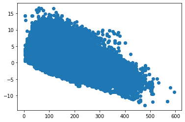

```python
import matplotlib.pyplot as plt
plt.scatter(data['psa'],data['alogp'])
```

DataFrames have a [useful method `corr`](https://pandas.pydata.org/pandas-docs/stable/reference/api/pandas.DataFrame.corr.html#pandas.DataFrame.corr), which calculates the correlations between columns.

1. Rank the properties in order of the strength of their correlation with `alogp`. (Discard `alogp` itself and the `cx_logp` property, which is a related prediction)

```python
corr = data.corr()
corr
```

|  | molregno | mw_freebase | alogp | hba | hbd | psa | rtb | num_ro5_violations | cx_most_apka | cx_most_bpka | cx_logp | cx_logd | full_mwt | aromatic_rings | heavy_atoms | qed_weighted | mw_monoisotopic | hba_lipinski | hbd_lipinski | num_lipinski_ro5_violations |
| --- | --- | --- | --- | --- | --- | --- | --- | --- | --- | --- | --- | --- | --- | --- | --- | --- | --- | --- | --- | --- |
| molregno | 1.000000 | 0.055303 | 0.078012 | 0.064863 | -0.067345 | -0.004067 | -0.051141 | 0.007956 | 0.091859 | -0.088816 | 0.061206 | 0.086955 | 0.051973 | 0.137684 | 0.062449 | 0.021814 | 0.055293 | 0.045685 | -0.066854 | -0.004468 |
| mw_freebase | 0.055303 | 1.000000 | 0.302989 | 0.646646 | 0.444852 | 0.644651 | 0.714203 | 0.781112 | -0.050841 | 0.201961 | 0.193116 | 0.082847 | 0.989849 | 0.348998 | 0.982782 | -0.722482 | 0.999997 | 0.741689 | 0.411300 | 0.788880 |
| alogp | 0.078012 | 0.302989 | 1.000000 | -0.220276 | -0.413369 | -0.397045 | 0.052907 | 0.288441 | 0.092280 | -0.114391 | 0.895166 | 0.804361 | 0.293758 | 0.556693 | 0.314242 | -0.180660 | 0.302409 | -0.295842 | -0.449183 | 0.190990 |
| hba | 0.064863 | 0.646646 | -0.220276 | 1.000000 | 0.445203 | 0.777874 | 0.496530 | 0.494415 | -0.082330 | 0.049642 | -0.227833 | -0.251567 | 0.638904 | 0.179075 | 0.634430 | -0.539939 | 0.647087 | 0.873367 | 0.437309 | 0.530094 |
| hbd | -0.067345 | 0.444852 | -0.413369 | 0.445203 | 1.000000 | 0.816963 | 0.544016 | 0.433308 | -0.183784 | 0.337041 | -0.454123 | -0.532234 | 0.447487 | -0.112876 | 0.436797 | -0.530443 | 0.445253 | 0.668419 | 0.971637 | 0.517038 |
| psa | -0.004067 | 0.644651 | -0.397045 | 0.777874 | 0.816963 | 1.000000 | 0.628028 | 0.526523 | -0.228671 | 0.167820 | -0.452054 | -0.512948 | 0.640241 | 0.023067 | 0.635793 | -0.617735 | 0.645172 | 0.942303 | 0.825270 | 0.619229 |
| rtb | -0.051141 | 0.714203 | 0.052907 | 0.496530 | 0.544016 | 0.628028 | 1.000000 | 0.574617 | -0.123489 | 0.292155 | -0.036189 | -0.157514 | 0.710926 | 0.064388 | 0.709337 | -0.642256 | 0.714540 | 0.641491 | 0.524325 | 0.619139 |
| num_ro5_violations | 0.007956 | 0.781112 | 0.288441 | 0.494415 | 0.433308 | 0.526523 | 0.574617 | 1.000000 | -0.104945 | 0.181597 | 0.182014 | 0.060594 | 0.775315 | 0.277611 | 0.766806 | -0.690892 | 0.781064 | 0.560086 | 0.405029 | 0.943107 |
| cx_most_apka | 0.091859 | -0.050841 | 0.092280 | -0.082330 | -0.183784 | -0.228671 | -0.123489 | -0.104945 | 1.000000 | -0.040500 | 0.235194 | 0.333780 | -0.051341 | 0.085824 | -0.025936 | 0.162446 | -0.050914 | -0.143166 | -0.154333 | -0.130546 |
| cx_most_bpka | -0.088816 | 0.201961 | -0.114391 | 0.049642 | 0.337041 | 0.167820 | 0.292155 | 0.181597 | -0.040500 | 1.000000 | -0.221248 | -0.294508 | 0.217908 | -0.170120 | 0.215706 | -0.184731 | 0.202240 | 0.149625 | 0.347097 | 0.216221 |
| cx_logp | 0.061206 | 0.193116 | 0.895166 | -0.227833 | -0.454123 | -0.452054 | -0.036189 | 0.182014 | 0.235194 | -0.221248 | 1.000000 | 0.904673 | 0.180627 | 0.494639 | 0.204151 | -0.094681 | 0.192547 | -0.350258 | -0.487143 | 0.086795 |
| cx_logd | 0.086955 | 0.082847 | 0.804361 | -0.251567 | -0.532234 | -0.512948 | -0.157514 | 0.060594 | 0.333780 | -0.294508 | 0.904673 | 1.000000 | 0.068698 | 0.465149 | 0.094500 | 0.005314 | 0.082287 | -0.393090 | -0.563179 | -0.029422 |
| full_mwt | 0.051973 | 0.989849 | 0.293758 | 0.638904 | 0.447487 | 0.640241 | 0.710926 | 0.775315 | -0.051341 | 0.217908 | 0.180627 | 0.068698 | 1.000000 | 0.339098 | 0.973115 | -0.717634 | 0.989855 | 0.734577 | 0.415364 | 0.784155 |
| aromatic_rings | 0.137684 | 0.348998 | 0.556693 | 0.179075 | -0.112876 | 0.023067 | 0.064388 | 0.277611 | 0.085824 | -0.170120 | 0.494639 | 0.465149 | 0.339098 | 1.000000 | 0.391087 | -0.341327 | 0.348889 | 0.118948 | -0.125617 | 0.241500 |
| heavy_atoms | 0.062449 | 0.982782 | 0.314242 | 0.634430 | 0.436797 | 0.635793 | 0.709337 | 0.766806 | -0.025936 | 0.215706 | 0.204151 | 0.094500 | 0.973115 | 0.391087 | 1.000000 | -0.716663 | 0.983076 | 0.739795 | 0.403290 | 0.777173 |
| qed_weighted | 0.021814 | -0.722482 | -0.180660 | -0.539939 | -0.530443 | -0.617735 | -0.642256 | -0.690892 | 0.162446 | -0.184731 | -0.094681 | 0.005314 | -0.717634 | -0.341327 | -0.716663 | 1.000000 | -0.722606 | -0.622139 | -0.499678 | -0.725714 |
| mw_monoisotopic | 0.055293 | 0.999997 | 0.302409 | 0.647087 | 0.445253 | 0.645172 | 0.714540 | 0.781064 | -0.050914 | 0.202240 | 0.192547 | 0.082287 | 0.989855 | 0.348889 | 0.983076 | -0.722606 | 1.000000 | 0.742221 | 0.411703 | 0.788926 |
| hba_lipinski | 0.045685 | 0.741689 | -0.295842 | 0.873367 | 0.668419 | 0.942303 | 0.641491 | 0.560086 | -0.143166 | 0.149625 | -0.350258 | -0.393090 | 0.734577 | 0.118948 | 0.739795 | -0.622139 | 0.742221 | 1.000000 | 0.655449 | 0.639178 |
| hbd_lipinski | -0.066854 | 0.411300 | -0.449183 | 0.437309 | 0.971637 | 0.825270 | 0.524325 | 0.405029 | -0.154333 | 0.347097 | -0.487143 | -0.563179 | 0.415364 | -0.125617 | 0.403290 | -0.499678 | 0.411703 | 0.655449 | 1.000000 | 0.498760 |
| num_lipinski_ro5_violations | -0.004468 | 0.788880 | 0.190990 | 0.530094 | 0.517038 | 0.619229 | 0.619139 | 0.943107 | -0.130546 | 0.216221 | 0.086795 | -0.029422 | 0.784155 | 0.241500 | 0.777173 | -0.725714 | 0.788926 | 0.639178 | 0.498760 | 1.000000 |

```python
import numpy as np
s = np.abs(corr['alogp']).sort_values(ascending=False)
s = s[2:]
s
```

```
cx_logd                        0.804361
aromatic_rings                 0.556693
hbd_lipinski                   0.449183
hbd                            0.413369
psa                            0.397045
heavy_atoms                    0.314242
mw_freebase                    0.302989
mw_monoisotopic                0.302409
hba_lipinski                   0.295842
full_mwt                       0.293758
num_ro5_violations             0.288441
hba                            0.220276
num_lipinski_ro5_violations    0.190990
qed_weighted                   0.180660
cx_most_bpka                   0.114391
cx_most_apka                   0.092280
molregno                       0.078012
rtb                            0.052907
Name: alogp, dtype: float64
```

Let's see if we can predict `alogp` using the top four properties.

We will use an [*ordinary least squares*](https://www.statsmodels.org/dev/examples/notebooks/generated/ols.html#examples-notebooks-generated-ols--page-root) model from the `scipy.statsmodels` package:

```python
import statsmodels.api as sm
```

1. Make a vector `y` containing the `alogp` values, and a 2D matrix `X` containing the corresponding values for your top four properties. *Hint: you may find `Series.index` useful here*

```python
y = data.alogp.values

X = data[s[:4].index].values
X
```

```
array([[ 2.42,  3.  ,  3.  ,  2.  ],
       [ 4.5 ,  2.  ,  2.  ,  2.  ],
       [ 5.16,  3.  ,  2.  ,  2.  ],
       ...,
       [-4.63,  3.  ,  4.  ,  3.  ],
       [ 0.1 ,  2.  ,  7.  ,  6.  ],
       [ 2.13,  1.  ,  5.  ,  3.  ]])
```

The matrix `X` is called our *design matrix*.

For our model to work correctly, it is important to add an additional column of constants to `X`. This corresponds to the y-intercept in a 2D linear equation:

```python
X = sm.add_constant(X)
X
```

```
array([[ 1.  ,  2.42,  3.  ,  3.  ,  2.  ],
       [ 1.  ,  4.5 ,  2.  ,  2.  ,  2.  ],
       [ 1.  ,  5.16,  3.  ,  2.  ,  2.  ],
       ...,
       [ 1.  , -4.63,  3.  ,  4.  ,  3.  ],
       [ 1.  ,  0.1 ,  2.  ,  7.  ,  6.  ],
       [ 1.  ,  2.13,  1.  ,  5.  ,  3.  ]])
```

Now we can fit the model:

```python
# make the model
model = sm.OLS(y, X).fit()

# make the predictions by the model
predictions = model.predict(X)

# Print out the statistics
model.summary()
```

OLS Regression Results

| Dep. Variable: | y | R-squared: | 0.693 |
| --- | --- | --- | --- |
| Model: | OLS | Adj. R-squared: | 0.693 |
| Method: | Least Squares | F-statistic: | 3.646e+05 |
| Date: | Tue, 03 Nov 2020 | Prob (F-statistic): | 0.00 |
| Time: | 11:35:12 | Log-Likelihood: | -9.8573e+05 |
| No. Observations: | 646622 | AIC: | 1.971e+06 |
| Df Residuals: | 646617 | BIC: | 1.972e+06 |
| Df Model: | 4 |  |  |
| Covariance Type: | nonrobust |  |  |

|  | coef | std err | t | P>\|t\| | [0.025 | 0.975] |
| --- | --- | --- | --- | --- | --- | --- |
| const | 1.2260 | 0.004 | 290.710 | 0.000 | 1.218 | 1.234 |
| x1 | 0.4893 | 0.001 | 696.891 | 0.000 | 0.488 | 0.491 |
| x2 | 0.4008 | 0.001 | 303.078 | 0.000 | 0.398 | 0.403 |
| x3 | -0.2204 | 0.003 | -78.210 | 0.000 | -0.226 | -0.215 |
| x4 | 0.2280 | 0.003 | 66.804 | 0.000 | 0.221 | 0.235 |

| Omnibus: | 75082.655 | Durbin-Watson: | 1.181 |
| --- | --- | --- | --- |
| Prob(Omnibus): | 0.000 | Jarque-Bera (JB): | 188576.590 |
| Skew: | 0.674 | Prob(JB): | 0.00 |
| Kurtosis: | 5.276 | Cond. No. | 17.9 |

Warnings:  
[1] Standard Errors assume that the covariance matrix of the errors is correctly specified.

1. Finally, plot the predictions against the real `alogp` values.

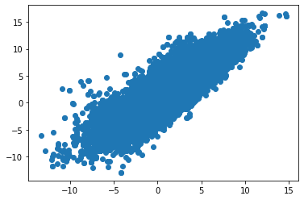

```python
plt.scatter(predictions,y)
```